# DSCI 310: Historical Horse Population in Canada

Author

Tiffany Timbers & Jordan Bourak

### Aim

This project explores the historical population of horses in Canada between 1906 and 1972 for each province.

### Data

Horse population data were sourced from the [Government of Canada’s Open Data website](http://open.canada.ca/en/open-data) (Government of Canada, 2017a and Government of Canada, 2017b).

### Methods

The R programming language (R Core Team 2019) and the following R packages were used to perform the analysis: knitr (Xie 2014), tidyverse (Wickham 2017), and Quarto (Allaire et al. 2022). *Note: this report is adapted from Timbers (2020).*

### Results

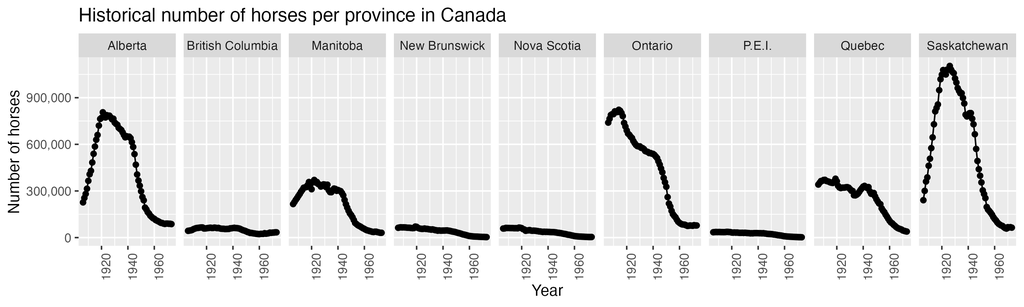

Figure 1: Historical horse populations in Canadian provinces from 1906 to 1972.

As shown in Figure 1, the number of horses recorded in each Canadian province varies across the study period. Ontario, Saskatchewan, and Alberta consistently appear among the provinces with the largest horse populations. A noticeable decline begins around the 1940s. One possible explanation for this pattern is the growing adoption of automobiles and mechanized farming equipment, which reduced the reliance on horses for transportation and agricultural work.

To further explore differences among provinces, we examine how much the horse population varied over time. The variability of the population counts is summarized using the standard deviation values shown in Table 1.

Table 1: Sample standard deviation of horse populations by Canadian province from 1906 to 1972.

| Province | Std |
| --- | --- |
| Saskatchewan | 377265.58 |
| Ontario | 266435.32 |
| Alberta | 266063.19 |
| Manitoba | 122403.87 |
| Quebec | 111411.10 |
| New Brunswick | 22019.49 |
| Nova Scotia | 19879.25 |
| British Columbia | 14945.66 |
| P.E.I. | 11355.75 |

The sample standard deviation is defined as

$$s = \sqrt{\frac{\sum_{i=1}^{N}(x_i - \overline{x})^2}{N-1}}$$

These values summarize the same time period illustrated in Figure 1.

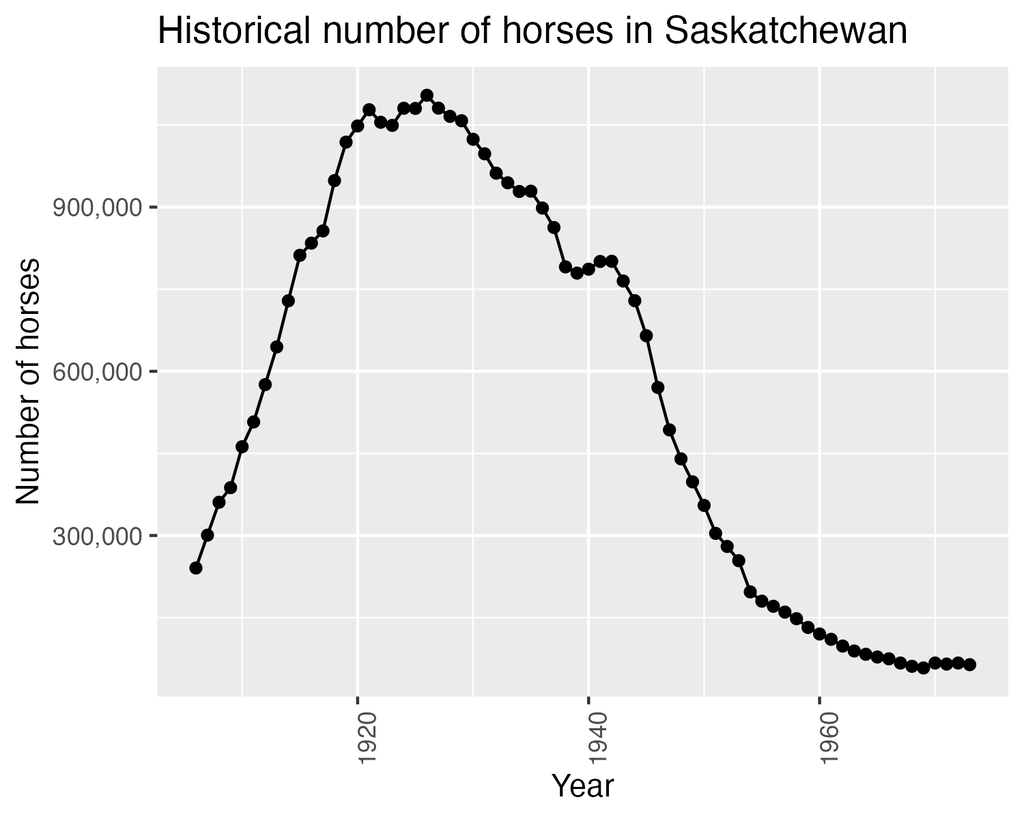

Figure 2: Horse population trend for the province with the highest variability.

Figure 2 focuses on the province with the greatest variation in horse population values. Based on the calculations in Table 1, the province with the largest standard deviation is Saskatchewan.

## References

Allaire, J. J., Charles Teague, Carlos Scheidegger, Yihui Xie, and Christophe Dervieux. 2022. “Quarto.” https://doi.org/10.5281/zenodo.5960048.

R Core Team. 2019. *R: A Language and Environment for Statistical Computing*. Vienna, Austria: R Foundation for Statistical Computing. https://www.R-project.org/.

Timbers, Tiffany. 2020. *Historical Horse Population in Canada*. https://github.com/ttimbers/equine_numbers_value_canada_parameters.

Wickham, Hadley. 2017. *Tidyverse: Easily Install and Load the ’Tidyverse’*. https://CRAN.R-project.org/package=tidyverse.

Xie, Yihui. 2014. “Knitr: A Comprehensive Tool for Reproducible Research in R.” In *Implementing Reproducible Computational Research*, edited by Victoria Stodden, Friedrich Leisch, and Roger D. Peng. Chapman; Hall/CRC. http://www.crcpress.com/product/isbn/9781466561595.